# BIRDWATCHER

This notebook takes you through the process of training and finetuning an image classifier on a self-curated dataset of 10 of the most-common birds found in Texas.  
We'll use the pytorch deep learning library to build and train the model. Given that the dataset has only a few hundred instances of each category, we'll use transfer learning to build a classifier. Transfer Learning is a useful technique in deep learning where we can use a model trained on a dataset that is different from our particular dataset, but is similar enough that the knowledge acquired by the model during its training can be reused for our task with a little fine-tuning.

Transfer Learning is specially useful when there aren't enough samples in a dataset to build a model from scratch or there aren't enough computational resources available to train from scratch complex models such as ResNet101. Transfer Learning proves to be an efficient and economic solution in such cases.

## Make the necessary imports

```python
import torch
import torch.nn as nn
import torchvision
from torchvision import datasets, models, transforms
import torch.optim as optim
from torch.optim import lr_scheduler
from tqdm import tqdm

import shutil
import matplotlib.pyplot as plt
import numpy as np
import os

from scikitplot.metrics import confusion_matrix
from sklearn.metrics import precision_score, recall_score, f1_score, accuracy_score
import itertools

import seaborn as sns
sns.set()

import copy
import time
```

```python
torch.manual_seed(0)
np.random.seed(0)
```

```python
!cp -r ../input/birdwatcher2/dataset2 ./train
```

### Separating train, test and validation images

```python
test_dir = './test/'
train_dir = './train'
train_ratio = 0.74
_, dirs, _ = next(os.walk(train_dir))
images_per_class = np.zeros(10) # 10 is number of classes
for i in range(10):
    path = os.path.join(train_dir,dirs[i])
    files = np.asarray(os.listdir(path))
    images_per_class[i] = len(files)

val_counter = np.round(images_per_class * (1-train_ratio))

# transfer files
for i in range(10):
    source_path = os.path.join(train_dir, dirs[i])
    dest_path = os.path.join(test_dir, dirs[i])
    if not os.path.exists(dest_path):
        os.makedirs(dest_path)
    files = np.asarray(os.listdir(source_path))
    for j in range(int(val_counter[i])):
        dst = os.path.join(dest_path, files[j])
        src = os.path.join(source_path, files[j])
        shutil.move(src,dst)
```

```python
test_dir = './val/'
train_ratio = 0.85
_, dirs, _ = next(os.walk(train_dir))
images_per_class = np.zeros(10) # 10 is number of classes
for i in range(10):
    path = os.path.join(train_dir,dirs[i])
    files = np.asarray(os.listdir(path))
    images_per_class[i] = len(files)

val_counter = np.round(images_per_class * (1-train_ratio))

# transfer files
for i in range(10):
    source_path = os.path.join(train_dir, dirs[i])
    dest_path = os.path.join(test_dir, dirs[i])
    if not os.path.exists(dest_path):
        os.makedirs(dest_path)
    files = np.asarray(os.listdir(source_path))
    for j in range(int(val_counter[i])):
        dst = os.path.join(dest_path, files[j])
        src = os.path.join(source_path, files[j])
        shutil.move(src,dst)
```

## Data Augmentations

The dataset curated by us has images of different of shapes. Before feeding images into the neural network its best to have the input standardized and normalized. Following transformations are applied to the images before feeding them into the network - images are resized to 256 x 256 x 3, randomly flipped along the vertical axis and normalized.

```python
data_transforms = {
    'train': transforms.Compose([
        transforms.Resize((256,256)),
#         transforms.RandomResizedCrop(224),
        transforms.RandomHorizontalFlip(),
        transforms.ToTensor(),
        transforms.Normalize([0.485, 0.456, 0.406], [0.229, 0.224, 0.225])
    ]),
    'val': transforms.Compose([
        transforms.Resize((256,256)),
        transforms.ToTensor(),
        transforms.Normalize([0.485, 0.456, 0.406], [0.229, 0.224, 0.225])
    ]),
    'test': transforms.Compose([
        transforms.Resize((256,256)),
        transforms.ToTensor()
    ]),
}
```

```python
#forming train, test and validation dataloaders
data_dir = './'
image_datasets = {x: datasets.ImageFolder(os.path.join(data_dir, x),
                                          data_transforms[x])
                  for x in ['train', 'val','test']}
dataloaders = {x: torch.utils.data.DataLoader(image_datasets[x], batch_size=4,
                                             shuffle=True, num_workers=4)
              for x in ['train', 'val', 'test']}
dataset_sizes = {x: len(image_datasets[x]) for x in ['train', 'val','test']}
class_names = image_datasets['train'].classes

device = torch.device("cuda:0" if torch.cuda.is_available() else "cpu")
```

```python
device
```

```
device(type='cuda', index=0)
```

```python
dataset_sizes
```

```
{'train': 1860, 'val': 327, 'test': 769}
```

```python
class_names
```

```
['American Coot',
 'Barn Owl',
 'Blue Jay',
 'Cattle Egret',
 'Eastern Screech Owl',
 'Great Blue Heron',
 'Neotropic Cormorant',
 'Northern Mockingbird',
 'Red Headed Woodpecker',
 'Redtailed Hawk']
```

Let's take a look at some images in our dataset.

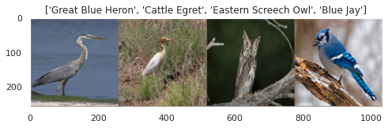

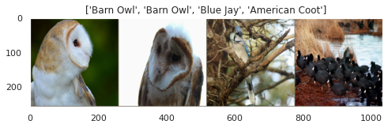

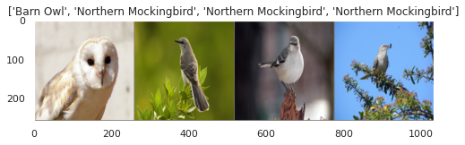

```python
def imshow(inp, title=None):
    """Imshow for Tensor."""
    inp = inp.numpy().transpose((1, 2, 0))
    mean = np.array([0.485, 0.456, 0.406])
    std = np.array([0.229, 0.224, 0.225])
    inp = std * inp + mean
    inp = np.clip(inp, 0, 1)
    fig = plt.figure(figsize=(8,8))
    plt.grid(False)
    plt.imshow(inp)
    if title is not None:
        plt.title(title)
#     plt.pause(0.001)  # pause a bit so that plots are updated

for i in range(3):
    # Get a batch of training data
    inputs, classes = next(iter(dataloaders['train']))

    # Make a grid from batch
    out = torchvision.utils.make_grid(inputs)

    imshow(out, title=[class_names[x] for x in classes])
```

We'll be using the following metrics to evaluate our models' performances - accuracy, f1-score, precision, recall and confusion matrix. The following cell initializes each of these metrics for training and validation datasets.

```python
train_metrics = {}
val_metrics = {}

train_metrics['accuracy'] = []
train_metrics['f1-score'] = []
train_metrics['precision'] = []
train_metrics['recall'] = []

val_metrics['accuracy'] = []
val_metrics['f1-score'] = []
val_metrics['precision'] = []
val_metrics['recall'] = []
```

## Model Training

The following function specifies how model training is performed. At the beginning of each epoch, all losses and predictions are reinitialized. For every batch of images in the training set, the model predicts the classes and the losses accumulated are backward propagated into the network. After each epoch, the model is run on the validation set and the performances are noted.

```python
def train_model(model, criterion, optimizer, num_epochs=25):

    start_time = time.time()

    best_model = copy.deepcopy(model.state_dict())
    best_val_acc = 0.0


    for epoch in tqdm(range(num_epochs)):

        model.train()  # Set model to training mode
        running_loss = 0.0
        running_corrects = 0
        y_true = []
        y_pred = []

        # Iterate over data.
        for inputs, labels in dataloaders['train']:
            inputs = inputs.to(device)
            labels = labels.to(device)

            # zero the parameter gradients
            optimizer.zero_grad()

            outputs = model(inputs)
            _, preds = torch.max(outputs, 1)
            loss = criterion(outputs, labels)

            loss.backward()
            optimizer.step()

            # statistics
            running_loss += loss.item() * inputs.size(0)
            running_corrects += torch.sum(preds == labels.data)

            y_true += labels.data.cpu()
            y_pred += preds.cpu()

        train_metrics['accuracy'].append(accuracy_score(y_true, y_pred))
        train_metrics['f1-score'].append(f1_score(y_true, y_pred, average="macro"))
        train_metrics['precision'].append(precision_score(y_true, y_pred, average="macro"))
        train_metrics['recall'].append(recall_score(y_true, y_pred, average="macro"))

        print('Train Accuracy: {}'.format(train_metrics['accuracy'][-1]))
        print('Train F1: {}'.format(train_metrics['f1-score'][-1]))
        print('Train Precision: {}'.format(train_metrics['precision'][-1]))
        print('Train Recall: {}'.format(train_metrics['recall'][-1]))


        model.eval()   # Set model to evaluate mode

        running_loss = 0.0
        running_corrects = 0
        y_true = []
        y_pred = []

        # Iterate over data.
        for inputs, labels in dataloaders['val']:
            inputs = inputs.to(device)
            labels = labels.to(device)

            outputs = model(inputs)
            _, preds = torch.max(outputs, 1)
            loss = criterion(outputs, labels)

            # statistics
            running_loss += loss.item() * inputs.size(0)
            running_corrects += torch.sum(preds == labels.data)

            y_true += labels.data.cpu()
            y_pred += preds.cpu()

        val_metrics['accuracy'].append(accuracy_score(y_true, y_pred))
        val_metrics['f1-score'].append(f1_score(y_true, y_pred, average="macro"))
        val_metrics['precision'].append(precision_score(y_true, y_pred, average="macro"))
        val_metrics['recall'].append(recall_score(y_true, y_pred, average="macro"))

        print('Val Accuracy: {}'.format(val_metrics['accuracy'][-1]))
        print('Val F1: {}'.format(val_metrics['f1-score'][-1]))
        print('Val Precision: {}'.format(val_metrics['precision'][-1]))
        print('Val Recall: {}'.format(val_metrics['recall'][-1]))

        if val_metrics['accuracy'][-1] > best_val_acc:
            best_val_acc = val_metrics['accuracy'][-1]
            best_model = copy.deepcopy(model.state_dict())

    time_elapsed = time.time() - start_time
    print(f'Training complete in {time_elapsed // 60:.0f}m {time_elapsed % 60:.0f}s')
    print(f'Best val Acc: {best_val_acc:4f}')

    # load best model weights
    model.load_state_dict(best_model)
    return model
```

## Freezing some layers of the model

```python
model_ft = models.resnet18(pretrained=True)

i=0
for param in model_ft.parameters():
    if(i>30):
        param.requires_grad = True
    i += 1
    param.requires_grad = False

num_ftrs = model_ft.fc.in_features
model_ft.fc = nn.Linear(num_ftrs, len(class_names))
model_ft = model_ft.to(device)
```

```
Downloading: "https://download.pytorch.org/models/resnet18-f37072fd.pth" to /root/.cache/torch/hub/checkpoints/resnet18-f37072fd.pth
```

We use CrossEntropy loss function as the criterion (the function that we want to minimize) and Adam optimizer with an initial learning rate of 5e-4 to train our model. We arrived at this learning rate after some trial and error. The user is encouraged to explore further - different combinations of hyperparameters to better train the model.

```python
criterion = nn.CrossEntropyLoss()

# Observe that all parameters are being optimized
optimizer_ft = optim.Adam(model_ft.parameters(), lr=0.0005)
```

```python
model_ft = train_model(model_ft, criterion, optimizer_ft,
                       num_epochs=15)
# Training the model for 15 epochs.
```

```
Train Accuracy: 0.5870967741935483
Train F1: 0.5861320143686704
Train Precision: 0.5889074053527195
Train Recall: 0.5879116563862616
```

```
Val Accuracy: 0.926605504587156
Val F1: 0.9266868280200876
Val Precision: 0.9333954471460915
Val Recall: 0.9263636363636364
```

```
Train Accuracy: 0.8204301075268817
Train F1: 0.821079852859213
Train Precision: 0.8218617229248529
Train Recall: 0.8212017655463091
```

```
Val Accuracy: 0.9571865443425076
Val F1: 0.9570503941327464
Val Precision: 0.9615776830482714
Val Recall: 0.9566666666666667
```

```
Train Accuracy: 0.8354838709677419
Train F1: 0.8363823168918584
Train Precision: 0.837214442286186
Train Recall: 0.8360424089645091
```

```
Val Accuracy: 0.963302752293578
Val F1: 0.9631546077889975
Val Precision: 0.9642764217123799
Val Recall: 0.9630303030303029
```

```
Train Accuracy: 0.8741935483870967
Train F1: 0.8748301081050001
Train Precision: 0.875647428849781
Train Recall: 0.8745400162884719
```

```
Val Accuracy: 0.9694189602446484
Val F1: 0.9694962121564972
Val Precision: 0.9706569900687547
Val Recall: 0.9690909090909091
```

```
Train Accuracy: 0.8725806451612903
Train F1: 0.8734842666645701
Train Precision: 0.875003079010957
Train Recall: 0.8727929758369017
```

```
Val Accuracy: 0.9694189602446484
Val F1: 0.9693000891126848
Val Precision: 0.9703007076022846
Val Recall: 0.9690909090909091
```

```
Train Accuracy: 0.8795698924731182
Train F1: 0.8801318864415574
Train Precision: 0.8805125256996252
Train Recall: 0.8799206253513049
```

```
Val Accuracy: 0.9694189602446484
Val F1: 0.969210705522163
Val Precision: 0.9700234932682751
Val Recall: 0.9690909090909091
```

```
Train Accuracy: 0.8946236559139785
Train F1: 0.8948508490177078
Train Precision: 0.8952594931065374
Train Recall: 0.8947089750795996
```

```
Val Accuracy: 0.9785932721712538
Val F1: 0.9784209642135864
Val Precision: 0.9800266276128344
Val Recall: 0.9781818181818182
```

```
Train Accuracy: 0.885483870967742
Train F1: 0.8855842457128414
Train Precision: 0.8861384541853923
Train Recall: 0.8855300731656257
```

```
Val Accuracy: 0.963302752293578
Val F1: 0.9632139973231013
Val Precision: 0.965057943830109
Val Recall: 0.9630303030303029
```

```
Train Accuracy: 0.8849462365591397
Train F1: 0.8856869181626772
Train Precision: 0.8866853627215899
Train Recall: 0.8852369569785493
```

```
Val Accuracy: 0.9755351681957186
Val F1: 0.9755060194036836
Val Precision: 0.9766901599349417
Val Recall: 0.9751515151515152
```

```
Train Accuracy: 0.8913978494623656
Train F1: 0.8916244736679294
Train Precision: 0.8919706223169077
Train Recall: 0.8914364148441019
```

```
Val Accuracy: 0.9724770642201835
Val F1: 0.9723815759016897
Val Precision: 0.9743827484395435
Val Recall: 0.9721212121212123
```

```
Train Accuracy: 0.8908602150537634
Train F1: 0.8910994172679996
Train Precision: 0.8915361994057707
Train Recall: 0.8909221607625863
```

```
Val Accuracy: 0.9663608562691132
Val F1: 0.9660169831397736
Val Precision: 0.9683216061544234
Val Recall: 0.9660606060606061
```

```
Train Accuracy: 0.8908602150537634
Train F1: 0.8914509669798563
Train Precision: 0.8918250271303162
Train Recall: 0.8912645580181613
```

```
Val Accuracy: 0.9724770642201835
Val F1: 0.9723115854083121
Val Precision: 0.9740551481119433
Val Recall: 0.972121212121212
```

```
Train Accuracy: 0.9010752688172043
Train F1: 0.9014215087230377
Train Precision: 0.9019177339306006
Train Recall: 0.9011551457330456
```

```
Val Accuracy: 0.9541284403669725
Val F1: 0.9542942249497024
Val Precision: 0.9579981510147919
Val Recall: 0.9539393939393939
```

```
Train Accuracy: 0.8989247311827957
Train F1: 0.8990574760928174
Train Precision: 0.8995098960537693
Train Recall: 0.8988635247660642
```

```
Val Accuracy: 0.9663608562691132
Val F1: 0.966034639193372
Val Precision: 0.9669056839036555
Val Recall: 0.9660606060606061
```

```
Train Accuracy: 0.8978494623655914
Train F1: 0.8983978573688501
Train Precision: 0.8988208452493665
Train Recall: 0.8982566246018544
```

```
Val Accuracy: 0.963302752293578
Val F1: 0.9632802075789803
Val Precision: 0.9644736429054379
Val Recall: 0.9630303030303031
Training complete in 20m 24s
Best val Acc: 0.978593
```

```python
#unfreeze full model
for param in model_ft.parameters():
    param.requires_grad = True
optimizer_ft = optim.Adam(model_ft.parameters(), lr=0.0001)

model_ft = train_model(model_ft, criterion, optimizer_ft,
                       num_epochs=10)
```

```
  cpuset_checked))
```

```
Train Accuracy: 0.8758064516129033
Train F1: 0.8765808726157813
Train Precision: 0.877064575731396
Train Recall: 0.8763777972992111
```

```
Val Accuracy: 0.9602446483180428
Val F1: 0.9606205900362662
Val Precision: 0.9642118049565868
Val Recall: 0.9596969696969696
```

```
Train Accuracy: 0.9193548387096774
Train F1: 0.9198786116630308
Train Precision: 0.9199353260680427
Train Recall: 0.9199026293672826
```

```
Val Accuracy: 0.9510703363914373
Val F1: 0.9516934753375736
Val Precision: 0.9555118139328667
Val Recall: 0.9509090909090909
```

```
Train Accuracy: 0.9397849462365592
Train F1: 0.9400077918454602
Train Precision: 0.9402030481214425
Train Recall: 0.9399042272000406
```

```
Val Accuracy: 0.9663608562691132
Val F1: 0.9665651617872383
Val Precision: 0.9686773467015403
Val Recall: 0.9660606060606061
```

```
Train Accuracy: 0.9548387096774194
Train F1: 0.9550812627654706
Train Precision: 0.9554649740252155
Train Recall: 0.9548249053053445
```

```
Val Accuracy: 0.9755351681957186
Val F1: 0.9757724131080646
Val Precision: 0.9766284695696461
Val Recall: 0.9754545454545454
```

```
Train Accuracy: 0.967741935483871
Train F1: 0.9679338646441806
Train Precision: 0.9679461495451838
Train Recall: 0.9679907748713514
```

```
Val Accuracy: 0.9571865443425076
Val F1: 0.9571779285899791
Val Precision: 0.958706550802139
Val Recall: 0.956969696969697
```

```
Train Accuracy: 0.9698924731182795
Train F1: 0.9699921645722215
Train Precision: 0.9701445082700164
Train Recall: 0.9699092211635107
```

```
Val Accuracy: 0.9602446483180428
Val F1: 0.9605133036032418
Val Precision: 0.9624056041335454
Val Recall: 0.9600000000000002
```

```
Train Accuracy: 0.9672043010752688
Train F1: 0.9672438101707849
Train Precision: 0.9674195017480918
Train Recall: 0.9671713379228821
```

```
Val Accuracy: 0.944954128440367
Val F1: 0.9448562092728132
Val Precision: 0.9470317873721574
Val Recall: 0.9445454545454546
```

```
Train Accuracy: 0.964516129032258
Train F1: 0.9645470209012672
Train Precision: 0.964681448017835
Train Recall: 0.9644941993174664
```

```
Val Accuracy: 0.981651376146789
Val F1: 0.9816886517201988
Val Precision: 0.9827731092436975
Val Recall: 0.9815151515151517
```

```
Train Accuracy: 0.9591397849462365
Train F1: 0.9594195998238397
Train Precision: 0.9596706495959098
Train Recall: 0.9592870773018335
```

```
Val Accuracy: 0.9480122324159022
Val F1: 0.9484280067147232
Val Precision: 0.9509383753501401
Val Recall: 0.9478787878787879
```

```
Train Accuracy: 0.9822580645161291
Train F1: 0.9824032694097505
Train Precision: 0.982560102593507
Train Recall: 0.9823625098281928
```

```
Val Accuracy: 0.9663608562691132
Val F1: 0.9663294425511693
Val Precision: 0.9681266389576276
Val Recall: 0.9660606060606061
Training complete in 14m 4s
Best val Acc: 0.981651
```

The following curves show the progression of the performance metrics over the epochs. Note that with transfer learning it only took us 25 epochs to achieve a decent acccuracy. This is another reason why transfer learning is employed to solve deep learning problems. Using pre-trained complex, heavy networks as feature extractors allows our model to identify patterns within the data quickly, reducing the training iterations required.

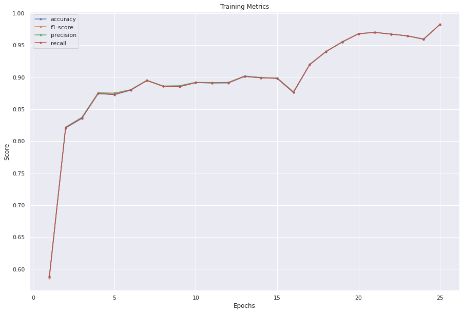

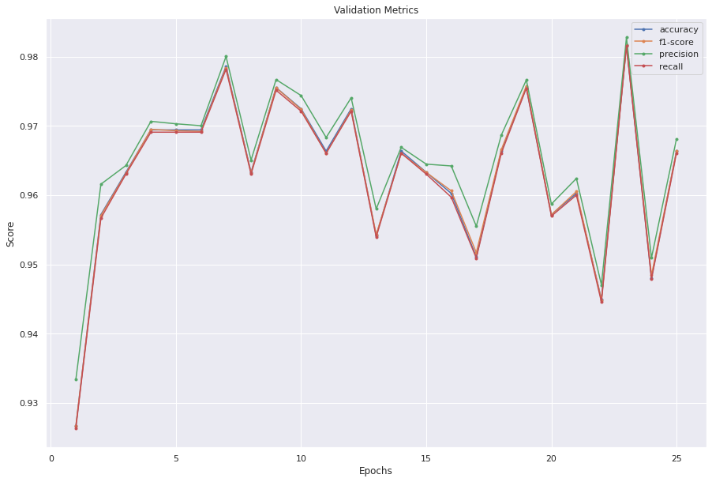

```python
#plotting train performances
fig = plt.figure(figsize=(15,10))
for k, v in train_metrics.items():
    plt.plot(range(1, len(v) + 1), v, '.-', label=k)
    # NOTE: changed `range(1, 4)` to mach actual values count
plt.title("Training Metrics")
plt.xlabel('Epochs')
plt.ylabel('Score')
plt.legend()  # To draw legend
plt.show()

#plotting train performances
fig = plt.figure(figsize=(15,10))
for k, v in val_metrics.items():
    plt.plot(range(1, len(v) + 1), v, '.-', label=k)
    # NOTE: changed `range(1, 4)` to mach actual values count
plt.title("Validation Metrics")
plt.xlabel('Epochs')
plt.ylabel('Score')
plt.legend()  # To draw legend
plt.show()
```

## Performance on the test set

Now that our model is trained, let's see how it performs on data it has never seen before. Our model's performance on the test set gives us an idea about how the model will perform once deployed in a real-world application.

```python
model_ft.eval()   # Set model to evaluate mode

running_loss = 0.0
running_corrects = 0
y_true = []
y_pred = []

# Iterate over data.
for inputs, labels in tqdm(dataloaders['test']):
    inputs = inputs.to(device)
    labels = labels.to(device)

    outputs = model_ft(inputs)
    _, preds = torch.max(outputs, 1)
    loss = criterion(outputs, labels)

    # statistics
    running_loss += loss.item() * inputs.size(0)
    running_corrects += torch.sum(preds == labels.data)

    y_true += labels.data.cpu()
    y_pred += preds.cpu()

val_acc = accuracy_score(y_true, y_pred)

print('Test Accuracy: {}'.format(val_acc))
print('Test F1: {}'.format(f1_score(y_true, y_pred, average="macro")))
print('Test Precision: {}'.format(precision_score(y_true, y_pred, average="macro")))
print('Test Recall: {}'.format(recall_score(y_true, y_pred, average="macro")))
```

```
  cpuset_checked))
```

```
Test Accuracy: 0.7204161248374512
Test F1: 0.7140006194181259
Test Precision: 0.7674934443529517
Test Recall: 0.7194780657938553
```

```python
def plot_confusion_matrix(cm, classes, name, normalize=True, title='Confusion matrix', cmap=plt.cm.Blues):

    """

    This function prints and plots the confusion matrix.

    Normalization can be applied by setting `normalize=True`.

    """

    plt.figure(figsize=(10,10))


    plt.imshow(cm, interpolation='nearest', cmap=cmap)

    plt.title(title)

    plt.colorbar()


    tick_marks = np.arange(len(classes))

    plt.xticks(tick_marks, classes, rotation=45)

    plt.yticks(tick_marks, classes)


    if normalize:

        cm = cm.astype('float') / cm.sum(axis=1)[:, np.newaxis]

        cm = np.around(cm, decimals=2)

        cm[np.isnan(cm)] = 0.0

        print("Normalized confusion matrix")

    else:

        print('Confusion matrix, without normalization')

    thresh = cm.max() / 2.

    for i, j in itertools.product(range(cm.shape[0]), range(cm.shape[1])):

        plt.text(j, i, cm[i, j],

                 horizontalalignment="center",

                 color="white" if cm[i, j] > thresh else "black")

    plt.tight_layout()
    plt.grid(b=None)
    plt.ylabel('True label')

    plt.xlabel('Predicted label')
    plt.savefig(f'./confusion_matrix_{name}.png')
```

```
Normalized confusion matrix
```

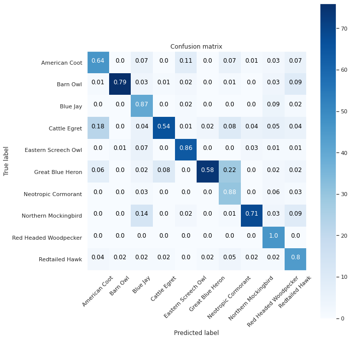

```python
cm = confusion_matrix(y_pred,y_true)
plot_confusion_matrix(cm,class_names,name='resnet18')
```

### Saving the model

```python
#save_model
torch.save(model_ft, "./birdwatcher.pth")
```